# How accurate is the YIELD Function in Excel?

The YIELD function is trusted by fixed income managers and has become the go-to source for reliable yield calculation. There are many ways to calculate yield based on the present value formula. The eventual result really depends on how much detail you put into the formula.

I will not explain in detail how to calculate yield from start to finish, but show you some examples that compare the yields produced by Excel and R BondValuation. Contact me if you have any comments or want to learn how to calculate and I can send you the spreadsheet. These two adopt the same generally accepted formula which you can find in the Microsoft Excel Help File (see below). Both have high levels of precision and iterations. This similarity is the reason why R BondValuation is appropriate for doing this comparison. So what cause the discrepancies?

Before I start, I would like to conclude that if you are a trader or analyst who do not look past 3 decimal places, then from that perspective, Excel is very reliable. However, if you are just curious or have always wondered whether your system vendors are telling the truth, then hopefully this will help you gain a better understanding. I’m not saying what algorithms other systems use, or what the “true” yield is but rather this is about Excel’s method of computation.

#### Excel Yield Function

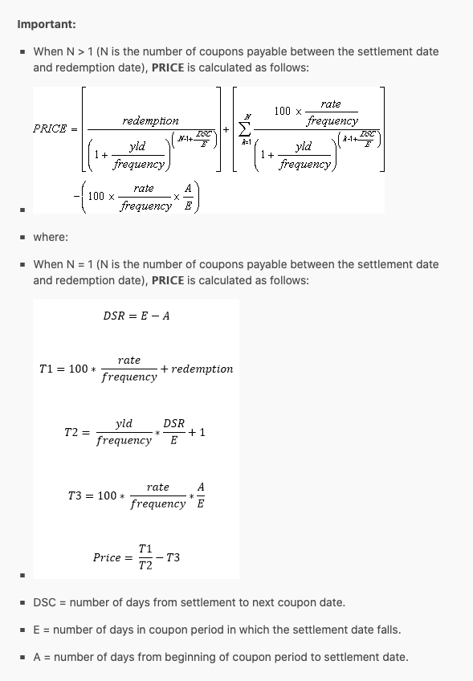

*Source: Excel Help File*

Unless the settle date falls within the last coupon period before maturity, Excel uses this Price formula to run iterations to generate the yield. What the formula says is:

1. If the settlement date is on a coupon payment date, the n-th period follows the number of coupon payments remaining until maturity. For example, if you buy a bond exactly 2 years from maturity, then there are four payments to look forward to if it pays semi-annually. For each coupon, discount it using t=1,2,3 and 4.
2. If the settlement date is between two coupon dates, then you need to find the proportion of days between settle date and next coupon date to total number of days in the that period. That fractional amount will be the added to each coupon period following the next coupon date. Because the date is within the accrual period, the accrued interest paid must be deducted from the sum of the present value.

Now, if you notice, the formula contains this coupon payment calculation:

$100* \frac{rate}{frequency}$

this is where the giveaway is as to why differences occur. This is a generic formula to derive the periodic coupon amount. Because of this formula, the day count convention, especially ACT/365, will affect the way coupon days, amount and period t are calculated. These are shown in the examples below.

#### Example 1

**Settle date = coupon date (no accruals)**

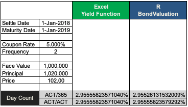

The bond yield is calculated using both ACT/365 and ACT/ACT day count convention (DCC). Using these yield, I create payment schedules to test the accuracy of yield and PV based on cash flows from different DCCs.

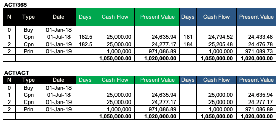

Notice that for ACT/ACT, Excel and R have the same yield (equal digits up to 10 d.p. gives the same PV). However, you may be wondering why Excel’s ACT/365 is the same as ACT/ACT. This is because the number of days for each coupon period is 182.5, which means Excel does not do date-specific day calculation. Rather, it takes the 365 and divide by 2, resulting in equal amounts, mirroring the ACT/ACT cash flow. R BondValuation does take into account date-specific range and hence able to calculate more precisely the correct amount to discount for each period.

#### Example 2

**Settle date falls in between 2 coupon periods**

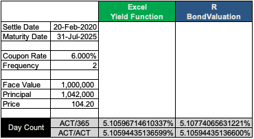

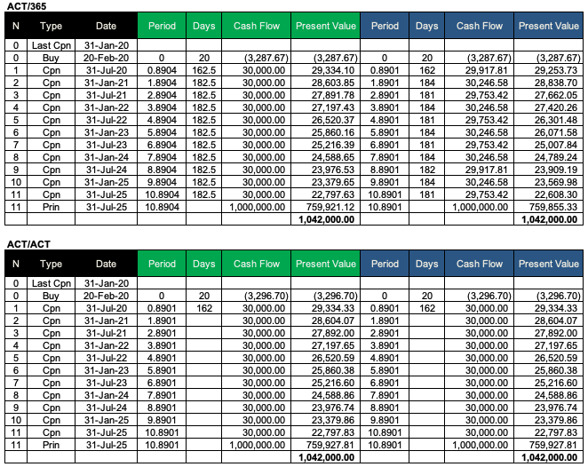

In this scenario, again, Excel uses 182.5 as the days in the period for ACT/365 throughout and the yield is very close to the ACT/ACT yield.

#### Conclusion

Excel does not calculate the exact number of days within a coupon period for ACT/365. (Note also, it is not ACT/365L which does not take into account leap years). If you are very particular about this, Excel’s YIELD function is not going to give you the most accurate numbers you want. The discrepancies may be larger if your bonds are long term or have irregular payment dates, modified following/preceding rules, or payment days are not equal to maturity day, etc. If your portfolio values are large, you may see big differences in your amortised book value or even other values that rely on yield (duration, etc.). This is not to say that the BondValuation package does everything accurately. It has some limitations, one of which is the coupon dates which do not get adjust for non-business day rules. Due to numerous characteristics of bonds worldwide, it is probably difficult to find a system that fully covers all types of bonds and conventions (see also other R Financial Packages such as RQuantlib). If you can’t find one that can closely replicate the actual cash flow of the bond you want to analyse, look no further than Excel itself. All you have to do is input the correct date, amount and time period, and run goal seek. The results are accurate but you will need to spend some time to setup the schedule manually. Not a good idea if you have many bonds in your portfolio.

Lastly, you saw in my post about constant yield amortisation and how the daily yield (using the rate function) is derived. Do not ever use daily cash flow to find a bond’s yield. That method assumes that you are re-investing daily accruals everyday, although the actual payment received is at least monthly for bonds. However, it is somewhat acceptable for amortisation purpose as it smooths out the curve and meets its target to amortise fully and uniformly the premium/discount amount.